# HW 2 Bolin Ji 1/27/2018

## Executive Summary

In this homework, we are exploring the stock return pattern before and after dividend date, and we would like to explore if there is any excess value of a strategy, which trades solely on the return pattern of all dividend paying stocks before and after dividend. Therefore, we would like to find all stocks that paid dividend in the past, and find the excess return over S&P 500 before and after the dividend payment. To be more precise, we label the returns by days before and after interest payment, and take the average of returns on each date. To find the volatility of return, we should also compute the standard deviation of return on each date. As a result, we found that the return on **12th** date after the dividend, which is **0.101%**, and the second highest return date is on the **4th** date after the dividend, which is **0.09%**, and the third highest return date is the **0th (diviend payment date)** date, which is 0.087%. On the other hand, the lowest average return comes from the **3rd** day after the dividend payment, which is **-0.104%**. The second lowest average return comes from the **2nd** day after the dividend payment, which is **-0.082%**. The third lowest average return comes from the **5th** date, which is **-0.058%**. Therefore, theoretically, if we long the dividend paying stock and short the market on the dividend payment date and 4th, and 12th dates after the dividend payment, and long the market while short the stock on the 2nd, 3nd and 5th dates after the dividend payment, then we should expect positive payoff. However, we also found that the volatility of the return is extremely high( above **1%**), and such high frequency long short strategy may incur significant loss.

## Full Body Text

#### 1. Concepts

Event Frequency Weighted Return: In this case, we are constructing portfolios that longs stocks and shorts S&P. The long-short positions for each stock is set to be equal so that the portfolio is market neutral, and the weight on each stock is based on the number of dividend payment in the past history.

Excess Return: In this case, the excess return is defined as the total return (including distribution) minus the market return (S&P 500). The excess return is equivalent to the return from a portfolio that longs the stock and short the market.

Arithmetic average: the sum of a series divided by the length of the series, which could be computed from the following function
$$A=\frac{1}{n}\sum_{i=1}^nR_i$$

#### 2. Assumptions

Stock: In this case, we assume the stocks should all be past or present S&P 500 stocks for two practical reason. First, it is more appropriate to compare the index with index composites. Second, these stock are fairly liquid, and the implicit transaction cost should not affect the return.

Market: In this case, we assume the market to be S&P 500.

Data Frame: In this case, we use the stock return from 2010 to 2016 because more recent data should provide more relevant information to predict future return.

#### 3. Data Source

In this case, we used data from WRDS->CRSP->Annual Update->Stock->Security Files->CRSP Daily Stock. Data was selected from 2010-01-01 to 2016-12-31, and we searched the entire database with Query Variables “Ticker”, “Holding Period Return”,“Return on S&P Composite”, “Dividend Cash Amount”

#### 4. Coding Process

1.Data Cleansing: First, we import our data from CSV file, then we would reformate the data with respective columns. For return, market return, and dividend, we would format them as numerical value. For Ticker, we would format them as text. Then, we would compute the difference between stock return and market return, and save the excess return as a column of the data. Since return that is reported as B or C or N/A is useless, we would filter the data by deleting all non-numerical return from the data.

2.Search Algorithm and Location Selection: In order to locate appropriate data, we would like to establish a search algorithm and find the location of the return data we need, instead of running the data in a loop multiple times. By implementing this search algorithm, we could largely reduce the computing time to **1 minute and 45 seconds**, and we would feed larger data to this algorithm.

In order to achieve this result, we would first locate the dividends in this dataset, and save the locations. Then, we would like to find the location of the return 20 days earlier from dividend and 20 days later from dividend. In some cases, we could not have data of return 20 days before and 20 days after dividend, then we should use the earliest available data for the begining point, and latest available for the ending point. Then, we would like to populate a continuous series of locations that centers at the dividend payment to the begining value and ending value. If the the length of a range is less than 20, we would save the location as 0. After doing so, we would use this table as a directory to locate each respective excess return data. and save these data to the respective columns. As a result, we would have a large table with 41 columns and multiple rows, where each column represents the date of the return with respect to the dividend. Then, we would take the mean and standard deviation of each column to reach our conclusion.

#### 5. Results

See the table and figures below

## Table and Figures

#### 1. Table of Return Before and After Dividend

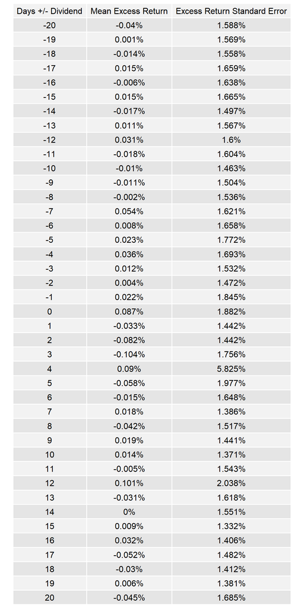

#### 2.Bar Graph of Return Before and After Dividend

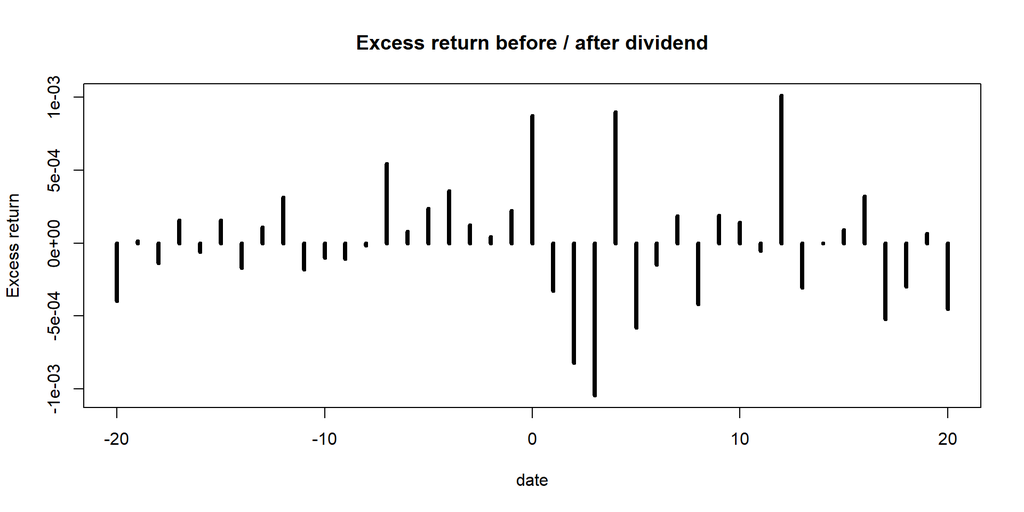

## Computer Code

library(xts)

library(gridExtra)

stock<-read.csv(“C:/Users/kuku/Desktop/MFE/Corp Fin/stock.csv”)

stock<-as.data.frame(stock)

stock$date<-as.Date(stock$date,format=“%m/%d/%Y”)

stock$DIVAMT<-as.numeric(as.character(stock$DIVAMT))

stock$RET<-as.numeric(as.character(stock$RET))

stock$sprtrn<-as.numeric(as.character(stock$sprtrn))

stock$diff<-stock$RET-stock$sprtrn

stock=stock[which(stock$RET>-1),]

tick<-unique(stock$TICKER)

tick<-as.character(tick)

n<-length(tick)

sum<-c()

endval<-c()

endval[1]=0

for (i in 2:(n+1)){

endval[i]<-max(which(stock$TICKER==tick[i-1]))

}

div<-which(stock$DIVAMT>0)

n1<-length(div)

startp<-data.frame()

endp<-data.frame()

for (i in 1:n){

dvd<-which(stock$DIVAMT[which(stock$TICKER==tick[i])]>0)+endval[i]

n2<-length(dvd)

if (n2==0){

```
next
```

}

startp[i,1]<-max(endval[i]+1,(dvd[1]-20))

for(j in 2:n2){

```
startp[i,j]<-dvd[j]-20
```

}

}

for (i in 1:n){

dvd<-which(stock$DIVAMT[which(stock$TICKER==tick[i])]>0)+endval[i]

n2<-length(dvd)

if (n2==0){

```
next
```

}

else{

if (n2>1){

for(k in 1:(n2-1)){

endp[i,k]<-dvd[k]+20

}

endp[i,n2]<-min(endval[i+1],dvd[n2]+20)

}

```
else\{
```

endp[i,n2]<-min(endval[i+1],dvd[n2]+20)

```
\}
```

}

}

startpoint<-as.numeric(na.omit(as.numeric(unlist(data.frame(t(startp))))))

endpoint<-as.numeric(na.omit(as.numeric(unlist(data.frame(t(endp))))))

loc1<-data.frame()

loc2<-data.frame()

loc3<-data.frame(rep(0,time=n1))

locvar<-c()

for (i in 1:n1){

locvar<-seq(from=div[i]-1,to=div[i]-20,by=-1)

for (j in 1:20)

if(locvar[j]>=startpoint[i]){

loc1[i,j]=locvar[j]

}

else{

```
next
```

}

locvar<-c()

}

for (i in 1:20){

loc3[,i]=loc1[,(21-i)]

}

for (i in 1:n1){

locvar<-seq(from=div[i]+1,to=div[i]+20,by=1)

for (j in 1:20)

```
if(locvar[j]<=endpoint[i])\{

  loc2[i,j]=locvar[j]

\}
```

else{

```
next
```

}

locvar<-c()

}

dividend<-as.matrix(div,ncol=1)

location<-cbind(loc3,dividend,loc2)

location[is.na(location)]=0

divret<-data.frame()

for (i in 1:n1){

for (j in 1:41){

```
lv=location[i,j]

if (lv>0)\{

divret[i,j]=stock\$diff[lv]

\}

else\{

divret[i,j]=NA

\}
```

}

}

mu<-as.matrix(rep(0,times=41),nrow=1)

for (i in 1:41){

mu[i]=mean(na.omit(divret[,i])) }

title<-c(“Days +/- Dividend”,“Mean Excess Return”,“Excess Return Standard Error”) dates<-seq(from=-20,to=20,by=1) miu<-paste(round(100*mu, 3), “%”, sep=“”) stdev1<-paste(round(100*stdev, 3), “%”, sep=“”) table1<-cbind(dates,miu,stdev1) table2<-rbind(title,table1) grid.table(table2)

plot(x=seq(from=-20,to=20,by=1),y=mu,type=“h”,main=“Excess return before / after dividend” ,ylab=“Excess return”,xlab=“date”)

# TAs, please don’t judge me too harshly